# Rainforest conversion to cash crops reduces abundance, biomass and species richness of parasitoid wasps in Sumatra, Indonesia - Azhar - - Agricultural and Forest Entomology - Wiley Online Library

[figure not shown]

ORIGINAL ARTICLE

Open Access

# Rainforest conversion to cash crops reduces abundance, biomass and species richness of parasitoid wasps in Sumatra, Indonesia

[Azru Azhar](https://resjournals.onlinelibrary.wiley.com/action/doSearch?ContribAuthorRaw=Azhar%2C+Azru),

[Tamara R. Hartke](https://resjournals.onlinelibrary.wiley.com/action/doSearch?ContribAuthorRaw=Hartke%2C+Tamara+R),

[Laura Böttges](https://resjournals.onlinelibrary.wiley.com/action/doSearch?ContribAuthorRaw=B%C3%B6ttges%2C+Laura),

[Tizian Lang](https://resjournals.onlinelibrary.wiley.com/action/doSearch?ContribAuthorRaw=Lang%2C+Tizian),

[Anik Larasati](https://resjournals.onlinelibrary.wiley.com/action/doSearch?ContribAuthorRaw=Larasati%2C+Anik),

[Nurul Novianti](https://resjournals.onlinelibrary.wiley.com/action/doSearch?ContribAuthorRaw=Novianti%2C+Nurul),

[Iqbal Tawakkal](https://resjournals.onlinelibrary.wiley.com/action/doSearch?ContribAuthorRaw=Tawakkal%2C+Iqbal),

[Purnama Hidayat](https://resjournals.onlinelibrary.wiley.com/action/doSearch?ContribAuthorRaw=Hidayat%2C+Purnama),

[Damayanti Buchori](https://resjournals.onlinelibrary.wiley.com/action/doSearch?ContribAuthorRaw=Buchori%2C+Damayanti),

[Stefan Scheu](https://resjournals.onlinelibrary.wiley.com/action/doSearch?ContribAuthorRaw=Scheu%2C+Stefan),

[Jochen Drescher](https://resjournals.onlinelibrary.wiley.com/action/doSearch?ContribAuthorRaw=Drescher%2C+Jochen),

First published: 13 May 2022

https://doi.org/10.1111/afe.12512

**Funding information:** Deutsche Forschungsgemeinschaft, Grant/Award Number: SFB 990-192626868

## Abstract

1. Parasitoid wasps affect herbivory in natural and agricultural ecosystems, including cash crops. The impacts of rainforest transformation to rubber and oil palm on parasitoid wasp communities are poorly understood.
2. We collected canopy arthropods, once each in dry season and rainy season, via canopy fogging in four land-use systems in Jambi, Sumatra, Indonesia: Rainforest, jungle rubber (extensive rubber cultivation) and plantations of rubber and oil palm.
3. The combined abundance and richness of six parasitoid wasp families, and Braconidae individually, was twice as high in rainforest as in rubber and oil palm plantations, and intermediary in jungle rubber. There was a significant positive correlation between combined abundance of six parasitoid wasp families, and abundances of potential hosts from the orders Coleoptera, Diptera, Hemiptera and Lepidoptera. Braconid biomass tended to be highest in rainforest and lowest in oil palm plantations, and Braconid communities in oil palm differed from those in the other land uses. Both patterns were influenced by season.
4. Our study details the effects of rainforest conversion to rubber and oil palm on parasitoid wasp communities, and provides first insights on the influence of rainfall seasonality on their abundance, biomass, species richness and community composition in Southeast Asian agricultural landscapes.

## INTRODUCTION

Agricultural expansion and intensification are among the most important drivers of environmental change and biodiversity loss worldwide (Matson et al., 1997; Tilman et al., 2001). While providing a growing human population with food and income, the often negative effects of agriculture on biodiversity may adversely affect human well-being (Díaz et al., 2006), largely through the tight link between biodiversity and ecosystem functioning (Tilman et al., 2014). Parasitoid are ‘insects whose larvae develop by feeding on the bodies of other arthropods’, which are mostly insects as well (Godfray, 1994). Parasitoids play a crucial role in terrestrial ecosystems in that they substantially contribute to the reduction of herbivore populations (Godfray, 1994; Quicke, 2015). Low levels of herbivory are associated with increased levels of plant growth (Dyer et al., 1993), which in turn contributes to overall animal biodiversity (Bascompte & Jordano, 2007). Partially due to their high degree of host specificity, parasitoid insects are highly diverse, currently representing approximately 10% of all known insect species (Heraty, 2017).

With the bulk of parasitoid abundance and species richness found in the apocrite Hymenoptera (Godfray, 1994; Heraty, 2017; Santos & Quicke, 2011), parasitoid wasps are the largest of all parasitoid insect taxa. Despite high numbers of described species, there is much uncertainty about the number of extant species in the parasitoid Hymenoptera. The superfamily Chalcidoidea alone, for example, contains some 22,500 described species, but their overall diversity is estimated at more than 500,000 species (Heraty, 2017; Noyes, 2019). Likewise, two of the most prominent families of parasitoid wasps, the Ichneumonidae and the Braconidae, currently have approximately 23,000 and 18,000 described species, respectively; these numbers, however, certainly are a great underestimate (Quicke, 2015). The small proportion of described species (Linnéan shortfall, see Brito, 2010), and the even smaller proportion of species with known biology, highlights a vast knowledge gap within the parasitoid Hymenoptera. This is especially true for parasitoid wasp communities from the paleotropics, whose abundances, biomass, species richness or community composition across natural and agricultural ecosystems have thus far received very little attention.

Two of the most important cash crops in Southeast Asia are natural rubber (*Hevea brasiliensis*) and oil palm (*Elaeis guineensis*). With a combined export value of 21 billion USD in 2020 (Badan Pusat Statistik, 2021), rubber and oil palm add substantially to the economy of Southeast Asia's most populous country, Indonesia. Here, rubber and oil palm cover ca. 3.7 and 14.9 Mha, respectively, with almost all of the rubber acreage and nearly half of the oil palm acreage farmed by smallholders (Badan Pusat Statistik, 2020a, 2020b). While on the one hand providing smallholder farmers with stable income (Sibhatu et al., 2022) following large-scale transmigration projects to alleviate poverty and overpopulation in Java since the 1980's (Fasbender & Erbe, 1990; Tsujino et al., 2016), rubber and oil palm cultivation leads to losses of ecosystem functions and biodiversity on the other (Clough et al., 2016; Drescher et al., 2016; Grass et al., 2020). Much of Indonesia's past and current deforestation can be attributed to stepwise conversion of rainforest into agricultural land, including rubber and oil palm plantations. With 0.84 Mha of rainforest lost in 2012, Indonesia had the highest deforestation rate of any tropical country (Margono et al., 2014), and is estimated to have lost 9.75 Mha of rainforest between 2002 and 2020 (Hansen et al., 2013; Turubanova et al., 2018). We therefor consider lowland rainforest as a reference system in this study, to understand what the original state of parasitoid wasp communities may have been prior to the conversion into agricultural land. We also include ‘jungle rubber’ in our study, an extensive rubber cultivation, which resembles degraded forest in which rubber trees have been planted (Rembold et al., 2017). This form of rubber cultivation is unique to Sumatra (Gouyon et al., 1993), and represents a land use intermediate between monoculture plantations of rubber and oil palm on the one hand, and lowland rainforest on the other.

Our study thus aims to unravel the effects of land-use change from rainforest via jungle rubber to monocultures of rubber and oil palm plantations on parasitoid wasp communities in tropical Southeast Asia. First, we compare the combined abundance and morphospecies richness of six families (Braconidae, Ceraphronidae, Encyrtidae, Eulophidae, Scelionidae and Platygastridae) between the four land-use systems. We also compare their combined abundance to the abundance of four potential host orders from the same sites, that is, Coleoptera, Diptera, Hemiptera and Lepidoptera. Second, we focus on the most species-rich family, Braconidae, to compare their biomass and community composition in addition to abundance and morphospecies richness between the four land-use systems, taking into account samples collected once in each of two seasons, that is, dry season and rainy season. Since it has been repeatedly shown that monocultures of rubber and oil palm host smaller populations and fewer species than lowland rainforest across a range of animals, including ants (Nazarreta et al., 2020; Rizqulloh et al., 2021), birds (Prabowo et al., 2016), butterflies (Panjaitan et al., 2020), frogs (Paoletti et al., 2018) and spiders (Junggebauer et al., 2021; Potapov et al., 2020), we expected the following patterns:

1. Combined parasitoid wasp abundance and morphospecies richness of six families would be highest in lowland rainforest, intermediate in jungle rubber and lowest in rubber and oil palm monocultures.
2. Abundances of potential hosts, for example, Coleoptera, Diptera, Hemiptera and Lepidoptera, would show significant, positive correlations with the combined abundance of six parasitoid families.
3. Braconid abundance, morphospecies richness and biomass would be highest in lowland rainforest, intermediate in jungle rubber and lowest in rubber and oil palm.
4. Based on previous research on ants, butterflies and spiders in the same plots (Junggebauer et al., 2021; Nazarreta et al., 2020; Panjaitan et al., 2020), we expected community composition of Braconid wasps to be similar between lowland rainforest and jungle rubber, but different from rubber and oil palm, which in turn would differ from each other.
5. Additionally, we explored the potential effect of seasonality on Braconid wasp abundance, morphospecies richness, biomass and community composition. As we found no literature investigating the effects of different rainfall patterns on either plant pests or parasitoid wasps in Southeast Asia, and as we only sampled once in each season (see Methods), we expected no differences in either Braconid wasp community metrics between seasons.

## METHODS

### Sample collection

Canopy fogging was carried out in three locations per 50 m × 50 m plot, using the Swingfog® SN50 fogger (Swingtec GmbH, Germany) to apply a mixture of 50 ml DECIS 25 EC® (Bayer Crop Science, active ingredient deltamethrine, 25 g/L) dissolved in four litres of petroleum white oil to each of the targeted canopies. Target canopies were established in a roughly equidistant triangle within the EFForTS core plots, with the respective target canopies being approx. 40 m apart. The orientation of the triangle with respect to the sides of the EFForTS plot square was random, but canopy gaps and overly dense understory was avoided. Canopy fogging was conducted at sunrise to avoid temperature induced turbulences at later times of the day, and only in dry conditions to ensure sample comparability between dry and rainy season. Underneath each target canopy, we placed 16 square collection funnels, each measuring 1 m × 1 m, suspended from ropes tied to height-adjustable metal poles and fitted with 250 ml PE bottles containing 100 ml 95% EtOH. Two hours after the application of the insecticide, collection funnels were removed, arthropod samples were cleaned of debris, EtOH exchanged, and combined into a single sample per target canopy per plot. Canopy fogging was conducted twice, once between May and September 2013 and again between November 2013 and March 2014, always at least 6 months apart for a given plot. The two sampling campaigns fall into times with considerably different rainfall patterns (Figure S2), and are thus referred to as dry season (May–September) and rainy season (November–March).

### Sorting and body mass estimation

Across the two sampling campaigns, 539,618 individuals from 12 of the most abundant canopy arthropod orders were collected and counted (Drescher, unpublished data): Acarina, Araneae, Blattodea, Coleoptera, Collembola, Diptera, Hemiptera, Hymenoptera, Lepidoptera, Orthoptera, Psocoptera and Thysanoptera. The abundances of Coleoptera, Diptera, Hemiptera and Lepidoptera (overall more than 150,000 individuals), were further used in the present study in correlation analyses with parasitoid wasp abundances, as all four of those orders are well-known hosts for parasitoid wasps (Godfray, 1994).Parasitoid wasps formed the second most abundant taxonomic group within the Hymenoptera in our collection (after the ants, Formicidae), and we considered wasps from the six overall most abundant families for further analysis: Braconidae, Ceraphronidae, Eulophidae, Encyrtidae, Platygastridae and Scelionidae. Ichneumonidae were excluded from further analyses due to very low abundances, suggesting sampling bias against them (D. Quicke, pers. comm.). This may be due to Ichneumonidae actively evading the insecticide cloud produced by canopy fogging, as was observed for several winged taxa during sample collection, incl. larger bees, wasps and dragonflies (J. Drescher pers. obs.). Collected individuals of Braconidae, Ceraphronidae, Eulophidae, Encyrtidae, Platygastridae and Scelionidae from the dry season 2013 were sorted to morphospecies, and in addition, Braconid parasitoid wasps from the rainy season sampling campaign. Morphospecies sorting is a common practice in biodiversity monitoring approache (Abadie et al., 2008; Bolger et al., 2000; Oliver & Beattie, 1993) and an necessary procedure when faced with taxa such as parasitoid wasps, where the overwhelming majority of encountered species are not formally described (Godfray, 1994; Quicke, 2015). A possible limitation of the morphospecies approach is that species numbers may differ between an amateur and a taxonomic expert, potentially hampering multivariate analyses (Krell, 2004). In the present study, however, comparisons between land-use systems are relative rather than absolute, and morphospecies numbers are likely underestimations of true species richness of parasitoid wasps, especially in rainforest (D. Quicke, pers. comm.). The morphospecies collection is still part of taxonomic revision and serves as reference to sorting of later collections. Once ongoing work is completed, the morphospecies collection will be deposited in facilities of the Indonesian Institute of Sciences of Indonesia, LIPI. A preliminary presentation of dry season data after a first round of sorting was published in Tawakkal et al. (2020), and morphospecies richness per plot of the six focal families was included in Grass et al. (2020).

Biomass of Braconid wasps per square meter was calculated by first estimating the average individual live body mass (IBM) per plot using the Length-Width-Taxon Region (LWTR) model in Sohlström et al. (2018), using ‘Hymenoptera’ as taxon and ‘tropical’ as region, and mean values of body length and body width of 15 randomly selected Braconidae specimen per plot, followed by multiplication of the resulting IBM with the abundance per square meter per plot. Average Braconid wasp body length and width per plot was measured on a Zeiss Stemi 2000 dissecting microscope to the nearest 0.1 mm using 15 randomly selected individuals per plot. Body length was defined as the longest distance that could be measured between the most anterior part of the head capsule, and the most posterior part of the abdomen, using a flattened-out specimen in dorsal view without distorting the head position of individuals. Body width was defined as the widest part that could be measured on the thorax, orthogonally to body length, from dorsal view. Abundance per square meter (N/m<sup>2</sup>) was calculated for each plot by dividing the total abundance of Braconid wasps collected in a plot (*N*<sub>plot</sub>) by the number of collecting traps used in a plot, that is, N/m<sup>2</sup> = *N*<sub>plot</sub>/(3 * 16).

### Statistical analyses

Statistical analyses were performed using R v. 4.0.5 (R Core Team, 2020) and visualized using ggplot2 (Wickham, 2016). First, we calculated Venn diagrams of cumulative species overlap between land-use systems and landscapes for the six parasitoid families combined using venn.js (Jol, 2015, https://github.com/benfred/venn.js). We then calculated species accumulation curves (SACs) using the function *specaccum* in the vegan package (Oksanen et al., 2019) as well as rank abundance curves using *RankAbund* (Hartke, 2020), which we compared among land-use systems using the function *radfit* in the vegan package (Oksanen et al., 2019), both for the six-families dataset, and the braconid wasps separately. Where applicable, response variables ‘abundance per square meter’, ‘species richness’, ‘biomass, mg per m<sup>2</sup>’ and ‘inverse Simpson Index 1/*D*’ as an example of a diversity index taking into account species richness and evenness, calculated with the function *diversity* in the vegan package, Oksanen et al. (2019), were compared between land-use systems, with landscape, season and all possible interactions as fixed factors in a Generalized Linear Model (glm) with appropriate family and link functions. Models were simplified in a step-wise fashion based on AIC (Aikake Information Criterium), followed by multiple comparisons using Tukey's HSD test using the function *glut* in the package multcomp (Hothorn et al., 2008). Correlations between the abundance of parasitoid wasps of six families per plot per season and abundances of four potential arthropod host orders per plot per season (Coleoptera, Diptera, Hemiptera, Lepidoptera, the latter both adults and larvae), were analysed using Pearson's product moment correlation using the function *cor.test* in basic R (R Core Team, 2020). Community composition of braconid wasps was visualized as biplot of two latent variables based on model-based Bayesian ordination in the boral package (Hui, 2016; https://cran.r-project.org/package=boral) and compared among land-use systems using the function *manyglm* in the package mvabund (Wang et al., 2021).

## RESULTS

### Combined abundance and richness of six parasitoid wasp families

In the dry season 2013, 10,183 parasitoid wasp specimens of the six families Braconidae, Ceraphronidae, Encyrtidae, Eulophidae, Platygastridae and Scelionidae were collected across 96 individual canopy fogging events, i.e. three in each of 32 research plots. In total, Encyrtidae were the most abundant parasitoid wasp family (*N* = 2908), closely followed by Braconidae (*N* = 2811). Eulophidae (*N* = 1371) and Scelionidae (*N* = 1320) were represented by less than half the individuals than Encyrtidae and Braconidae, and Ceraphronidae (*N* = 910) and Platygastridae (*N* = 863) by less than a third. These specimens were sorted to 1181 morphospecies, with Braconidae being the most morphospecies rich (*S* = 309), followed by Scelionidae (*S* = 193), Platygastridae (*S* = 189), Encyrtidae (*S* = 169), Eulophidae (*S* = 168) and Ceraphronidae (*S* = 152). More than 90% of all morphospecies were found in either rainforest, jungle rubber or both, and almost 50% of all morphospecies were exclusively found there (Figure S3). Oil palm and rubber, on the other hand, were home to just over 50% of all morphospecies, and less than 10% of all morphospecies were exclusively collected from these land-use systems (Figure S3). The Bukit Duabelas and Harapan landscapes differed considerably in the number of parasitoid wasp morphospecies; just over half of all morphospecies were found in both landscapes, while a third were found exclusively in Bukit Duabelas, and one seventh exclusively in Harapan (Figure S4). SACs suggest that overall sampling was near complete, while sampling in rubber and oil palm appeared slightly closer to saturation than sampling in rainforest and jungle rubber (Figure S5).

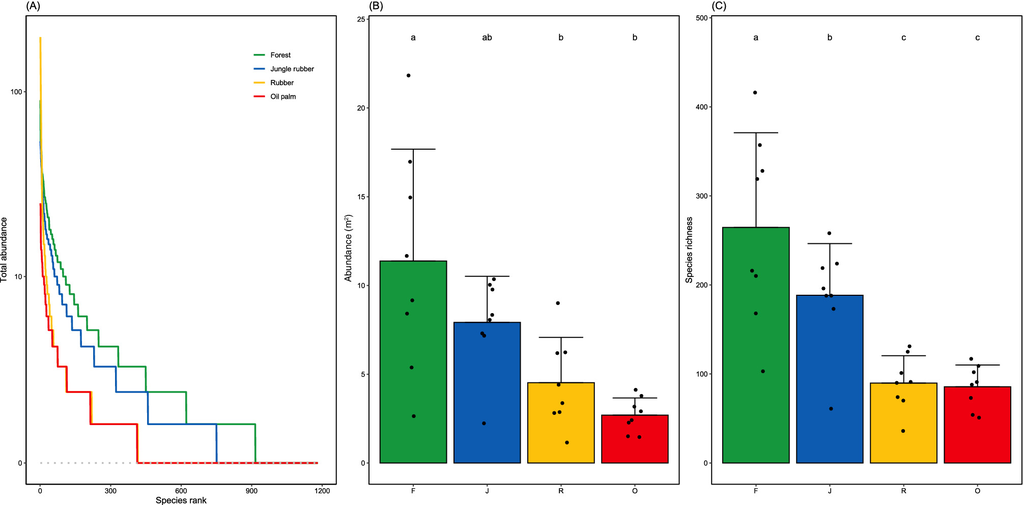

**FIGURE 1**

(a) Rank abundance curves, (b) average abundance (ind./m<sup>2</sup>) and (c) average species richness (number of species/m<sup>2</sup>) of six parasitoid wasp families in the dry season 2013 across four land-use systems in two landscapes in Jambi, Sumatra, Indonesia (green = rainforest, ‘F’; blue = jungle rubber, ‘J’; yellow = rubber, ‘R’; red = oil palm, ‘O’). Bars sharing the same letter do not differ significantly (Tukey's HSD test, α = 0.05)

Average abundance of the six families combined was significantly affected by land use (*F*<sub>3,28</sub> = 15.6, *p* <0.0001, Figure 1b), with parasitoid wasp abundances in rainforest almost two and a half times higher than in rubber and more than four times as high as in oil palm, with jungle rubber in an intermediate position. Landscape also influenced overall parasitoid wasp abundances (*F*<sub>1,27</sub> = 22.9, *p* <0.0001), most clearly in rainforest (Figure S6a). The factors landscape and land use did not interact significantly (*F*<sub>3,24</sub> = 2.2, *P* = 0.11). Similarly, average morphospecies richness was influenced by land use (*F*<sub>3,28</sub> = 37.2, *p* <0.0001) and by landscape (*F*<sub>1,27</sub> = 44.4, *p* <0.0001), without significant interaction between the factors (*F*<sub>3,24</sub> = 1.5, *P* = 0.25). Combined over landscapes, average parasitoid wasp morphospecies richness in rainforest was approximately three times as high as in rubber or oil palm, with jungle rubber in an intermediate position (Figure 1c). The influence of landscape on morphospecies richness was again strongest in rainforest, and the trend of decreasing morphospecies richness in the other land uses was consistent across landscapes (Figure S6b). Average parasitoid wasp diversity, calculated as Inverse Simpson's Index 1/*D*, was likewise significantly affected by land use (*F*<sub>3,28</sub> = 21.3, *p* <0.0001) and landscape (*F*<sub>1,27</sub> = 31.4, *p* <0.0001). Overall, it was highest in rainforest, followed by jungle rubber, rubber and oil palm, however, this pattern was more pronounced in the Bukit Duabelas landscape, where 1/*D* values were also higher for each land-use system than in the Harapan landscape (Figure S7).

### Abundance correlations of six parasitoid wasp families and four potential host orders

Across both seasons and all 32 EFForTS core plots, 159,804 individuals of four potential host orders Coleoptera, Diptera, Hemiptera and Lepidoptera (adult and larvae combined) were collected. The abundance of each potential host order was significantly correlated with the combined abundance of six parasitoid wasp families (all *R*<sup>2</sup> >0.067, all *p* <0.002, Figure 2).

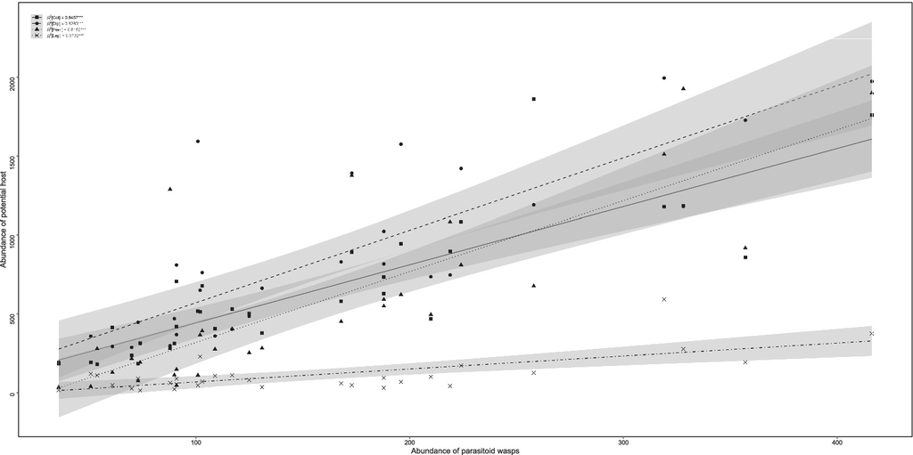

**FIGURE 2**

Abundance per plot of four potential host orders (‘Col’, squares, solid line: Coleoptera; ‘Dip’, circles, dashed line: Diptera; ‘Hem’, triangles, dotted line: Hemiptera; ‘Lep’, crossmarks, dashed dotted line: Lepidoptera) in relation to combined abundance per plot of six parasitoid wasp families. Grey shaded areas around regression lines represent 95% confidence intervals. The legend gives Pearson correlation coefficients and *p* values (‘***’: *p*≤0.001)

### Braconid wasps in dry and rainy season

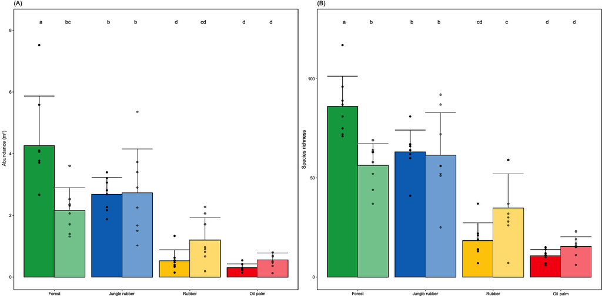

**FIGURE 3**

(a) Average abundance (ind./m<sup>2</sup>) and (b) average species richness (number of species/m<sup>2</sup>) of braconid wasps in the dry season 2013 and the rainy season 2013–2014 across four land-use systems in two landscapes in Jambi, Sumatra, Indonesia (green = rainforest; blue = jungle rubber; yellow = rubber; red = oil palm; bold colours = Bukit Duabelas; faded colours = Harapan). Bars sharing the same letter do not differ significantly (Tukey's HSD test, α = 0.05)

Average braconid biomass patterns across land-use systems, landscapes and seasons were more complex than those of abundance and species richness. Braconid biomass was significantly affected by land use (*F*<sub>3,60</sub> = 4.7, *p* = 0.005) and marginally significantly by season (*F*<sub>1,58</sub> = 2.8; *p* = 0.098). Landscape did not affect average braconid biomass as a main effect, but significantly interacted with land use (*F*<sub>3,55</sub> = 3.3, *p* = 0.027) and season (*F*<sub>1,58</sub> = 10.8, *p* = 0.002). Average braconid biomass was highest in rainforest, intermediate in jungle rubber and lowest in rubber and oil palm, although groups were not separated significantly by post hoc comparison of means (Figure 4). Average braconid biomass from the rainy season was highest in Bukit Duabelas rainforest, and intermediate in Harapan rainforest and jungle rubber from both landscapes. However, biomass was particularly high in Harapan rubber, and at similarly low levels in Bukit Duabelas rubber and oil palm (Figure 4).

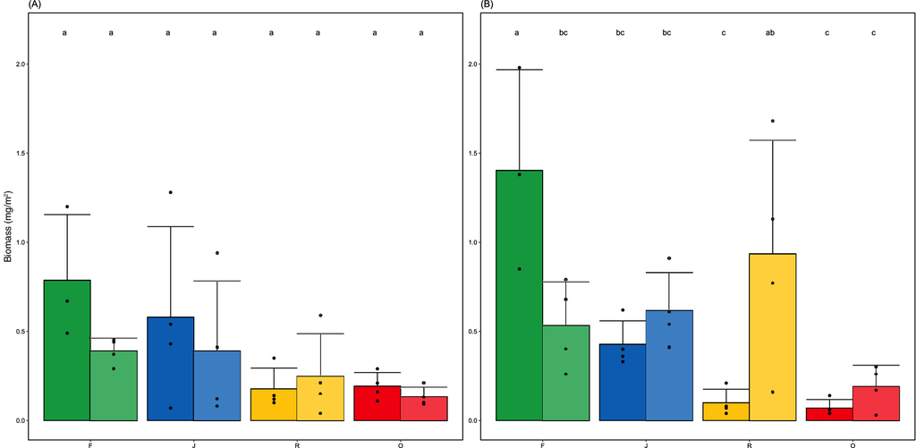

**FIGURE 4**

Average biomass (mg/m<sup>2</sup>) of braconid wasps in (a) dry season and (b) rainy season across four land-use systems in two landscapes in Jambi, Sumatra, Indonesia, (green = rainforest, blue = jungle rubber, yellow = rubber, red = oil palm; bold colours = Bukit Duabelas, faded colours = Harapan). Bars sharing the same letter do not differ significantly (Tukey's HSD test, α = 0.05)

Braconid wasp community composition was significantly influenced by land use, landscape and season (Wald >23.8, *p* ≤0.02), and all three factors interacted significantly in two-way (Wald >15.5, *p* ≤0.001) and three-way interactions (Wald = 11.3, *p* = 0.001). Across seasons, braconid community composition in rainforest of Bukit Duabelas was at least marginally different from braconid community compositions in rubber and oil palm in either landscape (Wald ≥525.9, all *p* ≤0.092). No other pairwise comparisons were statistically significant.

Bayesian ordination largely shows the same patterns as manyglm results in that Braconid wasp community composition is very similar between land-use systems in both seasons; however, Braconid wasp communities in oil palm tend to tend to separate from those in the other land-use systems (Figure 5).

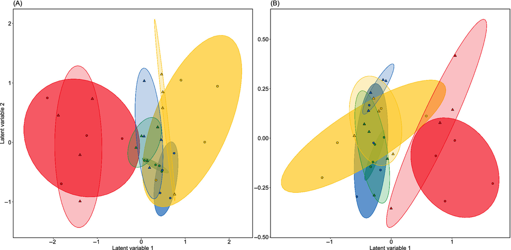

**FIGURE 5**

Latent variable biplot of ordination of braconid wasp community composition in (a) dry season and (b) rainy season across four land-use systems from two landscapes in Jambi, Sumatra, Indonesia (green = rainforest, blue = jungle rubber, yellow = rubber, red = oil palm; bold colours/triangles = Bukit Duabelas, faded colours/circles = Harapan)

## DISCUSSION

With the present study, we reveal how rainforest conversion to cash crops reduces abundance, biomass and species richness of parasitoid wasps in general, and braconid wasps in particular. By using samples collected twice, once in the dry season and once in the rainy season, we also give first insights into community composition changes of braconid wasp populations across seasons.

### Total parasitoid wasp and braconid wasp abundance, richness and biomass

It is important to note that species numbers presented here for the six families combined as well as Braconids individually are most certainly an underestimation of true species richness (D. Quicke, pers. comm.), which is moreover highly likely to underestimate species richness in rainforest more severely than in rubber or oil palm. The patterns observed and described here are thus probably based on a very conservative estimate of parasitoid richness and should be of much higher contrast between rainforest on the one hand and cash crop monocultures on the other if actual parasitoid species were known.

Braconid wasp biomass was highest in rainforest, intermediate in jungle rubber and lowest in the monoculture plantation systems of rubber and oil palm, supporting our third hypothesis. Braconid wasp abundance and species richness thus follows the general patterns observed in other canopy arthropod taxa along the same land-use gradient, including ants (Nazarreta et al., 2020), butterflies (Panjaitan et al., 2020) and spiders (Junggebauer et al., 2021; Potapov et al., 2020). This pattern was influenced by land use, landscape and season, the latter being severely limited in explanatory power, however, due to only one replicate being collected in either season.

Our expectation that community composition will be affected by land-use change (Hypothesis 4) was confirmed, albeit only partially. We expected braconid wasp community composition in forest and jungle rubber to be similar, but different from communities in oil palm, which is largely what we observed. We also expected the braconid wasp communities in rubber monocultures to be different from the three other systems, which was not the case. Instead, braconid wasp communities from rubber were very similar to those in rainforest and jungle rubber (rainy season) or differed only in trend (dry season). This absence of clear differentiation of braconid wasp community composition between rubber, forest and jungle rubber thus contrasts with patterns found in other taxa from our sampling sites including canopy ants (Nazarreta et al., 2020), butterflies (Panjaitan et al., 2020) and spiders (Junggebauer et al., 2021; Potapov et al., 2020). It is also unexpected as the community composition of Lepidoptera larvae, important hosts for parasitic wasps, recovered clear distinctions between rubber on the one hand, and jungle rubber and rainforest on the other (J. Drescher, unpub.). Finally, the present study provides first data on parasitoid wasp abundance, richness, biomass and community composition from dry season and rainy season in central Sumatra, Indonesia. Unfortunately, the observed patterns do not allow to draw general conclusions regarding seasonal patterns in parasitoid wasp communities, as each season was sampled only once. To the best of our knowledge, ours is the first study to present seasonal data on parasitoid wasps, especially for a rainforest to cash crop gradient, in Southeast Asia. As both the total as well as extreme precipitation in Southeast Asia is expected to rise with global change (Ge et al., 2019), the effects of rainfall seasonality on parasitoid wasps deserve increased attention, calling for repeated data collection over several consecutive years.

## CONCLUSION

The present study provides the first detailed analysis of land-use change effects on parasitoid wasp communities, especially braconid wasps, in South-East Asia. Specifically, we show that rainforest transformation to monocultures of rubber and oil palm reduces abundance, richness and biomass of parasitoid wasps and affects their community composition across seasons. This pattern is likely driven by declines of potential hosts populations. Our study shows that parataxonomic sorting to morphospecies is a useful tool for parasitoid wasp research on the community level. At the same time, out study highlights the Linnéan shortfall and the lack of species-specific biological information on the huge majority of parasitoid wasp species in Sumatra, emphasizing the dire need for increased species descriptions and species-specific research on parasitoid wasps in Southeast Asia.

## AUTHOR CONTRIBUTIONS

Jochen Drescher and Stefan Scheu designed the study; Jochen Drescher collected the wasp samples; Azru Azhar, Tizian Lang, Anik Larasati, Nurul Novianti, Iqbal Tawakkal sorted parasitoid wasp specimens to morphospecies under supervision of Damayanti Buchori, Purnama Hidayat and Jochen Drescher. Azru Azhar, Tizian Lang and Laura Böttges prepared the final data under supervision of Jochen Drescher; Azru Azhar, Tamara R. Hartke and Jochen Drescher analysed the data; Azru Azhar and Jochen Drescher led the writing of the manuscript. All authors contributed to the drafts and approved the final version of the manuscript.

## ACKNOWLEDGEMENTS

We thank Yohanes Toni Rohaditomo, Yohanes Bayu Suharto and Zulfi Kamal for help during sample collection, and Aiyen Tjoa, Barbara Wick, Wolfram Lorenz, Bambang Irawan, Heri Junedi and Rahadian Pratama for project coordination. This study was funded by the Deutsche Forschungsgemeinschaft (DFG, German Research Foundation) project number 192626868-SFB 990 in the framework of the collaborative German—Indonesian research project CRC990—EFForTS. We thank the following persons and organizations for granting access to and use of their properties: village leaders, local plot owners, PT Humusindo, PT REKI, PT Perkebunan Nusantara VI and Bukit Duabelas National Park. This study was conducted using samples/organisms collected based on Collection Permit No. S.710/KKH-2/2013 (PHKA, 23. Dec. 2013) and exported based on permit No. 773/KKH/SDG/KSA.2/2017 (PHKA, 04 August 2017). Three anonymous reviewers are thanked for providing detailed and constructive reviews. Donald Quicke is thanked for discussing opportunities and limitations of our parasitoid wasp data during a visit to Georg-August University of Göttingen to personally inspect our collected specimen. We acknowledge support by the Open Access Publication Funds of the Göttingen University. Open Access funding enabled and organized by Projekt DEAL.

## CONFLICT OF INTEREST

The authors declare no conflicts of interest.

## REFERENCES

[figure not shown]